# Capstone - Week2 - Milestone Report

Albert Shuxiang Li

March 23, 2016

## Introduction

This is a progress brief for my Coursera Data Science Capstone Project. The objective is to explain the Explortory Data Analysis which will lead to the eventual prediction app and algorithm.

The raw corpus data are located at my desktop hard desk:

- Blog “./data/Coursera-SwiftKey/final/en_US/en_US.blogs.txt”
- News “./data/Coursera-SwiftKey/final/en_US/en_US.news.txt”
- Twitter “./data/Coursera-SwiftKey/final/en_US/en_US.twitter.txt”

## Download and Unzip Raw Data

Download corpus dataset from Coursera data source [(Corpus Data Source)](https://d396qusza40orc.cloudfront.net/dsscapstone/dataset/Coursera-SwiftKey.zip) and then unzip it to local disk.

## Get Basic Information about Corpus Dataset

Here is the basic information retrived from raw corpus dataset. The code is attached as Appendix.

| FileName | FileSizeinMB | Lines | LinesNEmpty | Chars | CharsNWhite | WordCount |
| --- | --- | --- | --- | --- | --- | --- |
| en_US.blogs | 200.4242 | 899288 | 899288 | 206824382 | 170389539 | 37570839 |
| en_US.news | 196.2775 | 1010242 | 1010242 | 203223154 | 169860866 | 34494539 |
| en_US.twitter | 159.3641 | 2360148 | 2360148 | 162096031 | 134082634 | 30451128 |

## Sample and Clean

Random sampling method (12,000 lines per file) is justified because of the large corpus text data and my limited computation power.

Thereafter, a Document Term Matrix (DTM) is create for each corpus. The code fro this section is attached as Appendix.

## Plot Sampled Corpus Data with Word Cloud

[figure not shown]

## Ngrams Tokenization

The RWeka package has been used to develope Tokeniziers function in order to create unigram, bigram and trigram. And then ggplot2 package has been used to plot them.

The function “plot.Grams” is the self-defined function to implemente functionalities mentioed above. See appendix for the code details.

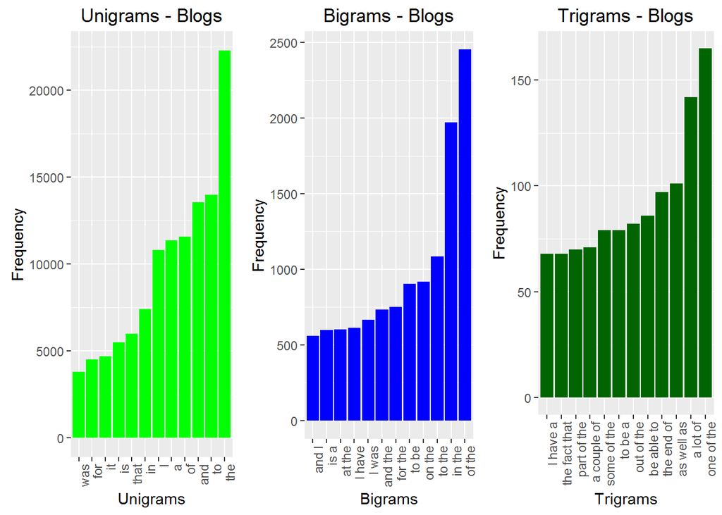

```r
library(ggplot2); library(gridExtra)
plot.Grams(x = sampleBlogs, subTitle = "Blogs", N = 12)
```

[figure not shown]

```r
plot.Grams(x = sampleNews, subTitle = "News", N = 12)
```

[figure not shown]

```r
plot.Grams(x = sampleTwitter, subTitle = "Twitter", N = 12)
```

## Further Development Plan

After the exploratory analysis, I think it is ready to start building the predictive model(s) and eventually the data product. Here is my further steps:

- Establish the predictive model(s) by using the tokens.
- Develop data product (i.e. shiny app) to make word prediction based on user inputs.

## Appendix - Code for Basic Information

```r
# Preload necessary R librabires
library(knitr); library(dplyr); library(doParallel)
library(stringi); library(tm); library(ggplot2); library(wordcloud)

path1 <- "./data/Coursera-SwiftKey/final/en_US/en_US.blogs.txt"
path2 <- "./data/Coursera-SwiftKey/final/en_US/en_US.news.txt"
path3 <- "./data/Coursera-SwiftKey/final/en_US/en_US.twitter.txt"

# Read blogs data in binary mode
conn <- file(path1, open="rb"); blogs <- readLines(conn, encoding="UTF-8"); close(conn)
# Read news data in binary mode
conn <- file(path2, open="rb"); news <- readLines(conn, encoding="UTF-8"); close(conn)
# Read twitter data in binary mode
conn <- file(path3, open="rb"); twitter <- readLines(conn, encoding="UTF-8"); close(conn)
# Remove temporary variable
rm(conn)

# Compute statistics and summary info for each data type
stats_for_raw <- data.frame(
            FileName=c("en_US.blogs","en_US.news","en_US.twitter"),
            FileSizeinMB=c(file.info(path1)$size/1024^2,
                           file.info(path2)$size/1024^2,
                           file.info(path3)$size/1024^2),
            t(rbind(sapply(list(blogs,news,twitter),stri_stats_general),
            WordCount=sapply(list(blogs,news,twitter),stri_stats_latex)[4,]))
            )
kable(stats_for_raw)
```

## Appendix - Code for Sample and Clean

```r
# Set random seed for reproducibility
set.seed(3606)
sampleBlogs <- blogs[sample(1:length(blogs), 12000, replace=FALSE)]
sampleNews <- news[sample(1:length(news), 12000, replace=FALSE)]
sampleTwitter <- twitter[sample(1:length(twitter), 12000, replace=FALSE)]

# Define a function to remove unconvention/funny characters
remove_funny <- function (x) {
  sampleX <- x
  for (i in 1:length(sampleX)) {
    original_row <- sampleX[i]
    cleaned_row <- iconv(original_row, "UTF-8", "ASCII", sub = "")
    sampleX[i] <- cleaned_row
  }
x <- sampleX
}

# Remove unconvention/funny characters for sampled Blogs/News/Twitter
sampleBlogs <- remove_funny(sampleBlogs)
sampleNews <- remove_funny(sampleNews)
sampleTwitter <- remove_funny(sampleTwitter)

# Save merged corpus samples to hard disk
# IF NEEDED, would write each sampled corpus to separated files
writeLines(sampleDat <- c(sampleBlogs, sampleNews, sampleTwitter), "./sample/sampleDat.txt")

# Remove temporary variables
rm(blogs, news, twitter, path1, path2, path3, sampleDat)

sampleDATA <- list(sampleBlogs, sampleNews, sampleTwitter)
# Create corpus and Document Term Matrix (DTM) vectors
corpus <- list()
dtMatrix <- list()
# Iterate each sampled corpus data to clean up and create DTM
for (i in 1:length(sampleDATA)) {
    # Create corpus dataset
    corpus[[i]] <- Corpus(VectorSource(sampleDATA[[i]]))
    # Cleaning Up corpus dataset
    corpus[[i]] <- tm_map(corpus[[i]], tolower)
    # Eleminate punctuation
    corpus[[i]] <- tm_map(corpus[[i]], removePunctuation)
    # Eleminate numbers
    corpus[[i]] <- tm_map(corpus[[i]], removeNumbers)
    # Strip Whitespace
    corpus[[i]] <- tm_map(corpus[[i]], stripWhitespace)
    # Eliminate profane words
    profanewords <- readLines("./docs/badwords.txt", n = 450)
    corpus[[i]] <- tm_map(corpus[[i]], removeWords, profanewords)
    # Eleminate English stop words
    corpus[[i]] <- tm_map(corpus[[i]], removeWords, stopwords("english"))
    # Perform stemming
    corpus[[i]] <- tm_map(corpus[[i]], stemDocument)
    # Create plain text format
    corpus[[i]] <- tm_map(corpus[[i]], PlainTextDocument)
    # Calculate document term frequency for corpus
    dtMatrix[[i]] <- DocumentTermMatrix(corpus[[i]], control=list(wordLengths=c(0,Inf)))
}
# Eleminate temporary variables
rm(sampleDATA)
```

## Appendix - Code for Plot of Sampled Corpus with Word Cloud

```r
library(wordcloud); library(slam)
# Set random seed for reproducibility
set.seed(3606)
# Set Plotting in 1 row 3 columns
par(mfrow=c(1, 3))
Headings= c("Word Cloud - US English Blogs",
            "Word Cloud - US English News",
            "Word Cloud - US English Twitter")

# Iterate each corpus and DTM and plot word cloud (Max = 100)
for (i in 1:length(corpus)) {
    wordcloud(words = colnames(dtMatrix[[i]]), freq = slam::col_sums(dtMatrix[[i]]),
        scale = c(3, 1), max.words = 100, random.order = FALSE, rot.per = 0.45,
        use.r.layout = FALSE, colors = brewer.pal(8, "Dark2"))
    title(Headings[i])
}
```

## Appendix - Code for Ngrams Tokenization

```r
library(tm); library(qdap); library(rJava)
.jinit(parameters="-Xmx128g")
library(RWeka); library(ggplot2); library(dplyr)

# Define a function to make Unigram, Bigram and Trigram from the corpus
# And then Plot them together with ggplot2 and gridExtra packages
plot.Grams <- function (x=sampleBlogs, subTitle="Blogs", N=10) {
# Use RWeka to get unigram token
Tokenizer1 <- RWeka::NGramTokenizer(x, Weka_control(min = 1, max = 1))
Gram.1 <- data.frame(table(Tokenizer1))
Gram.1 <- Gram.1[order(Gram.1$Freq, decreasing = TRUE),]
colnames(Gram.1) <- c("Word", "Freq")
Gram.1 <- head(Gram.1, N)
g1 <- ggplot(Gram.1, aes(x=reorder(Word, Freq),y=Freq)) +
        geom_bar(stat="identity", fill="green") +
        ggtitle(paste("Unigrams", "-", subTitle)) +
        xlab("Unigrams") + ylab("Frequency") +
        theme(axis.text.x=element_text(angle=90, hjust=1))
# Use RWeka to get bigram token
Tokenizer2 <- RWeka::NGramTokenizer(x, Weka_control(min = 2, max = 2,
                                                          delimiters = " \\r\\n\\t.,;:\"()?!"))
Gram.2 <- data.frame(table(Tokenizer2))
Gram.2 <- Gram.2[order(Gram.2$Freq, decreasing = TRUE),]
colnames(Gram.2) <- c("Word", "Freq")
Gram.2 <- head(Gram.2, N)
g2 <- ggplot(Gram.2, aes(x=reorder(Word, Freq),y=Freq)) +
        geom_bar(stat="identity", fill="blue") +
        ggtitle(paste("Bigrams", "-", subTitle)) +
        xlab("Bigrams") + ylab("Frequency") +
        theme(axis.text.x=element_text(angle=90, hjust=1))
# Use RWeka to get trigram token
Tokenizer3 <- RWeka::NGramTokenizer(sampleBlogs, Weka_control(min = 3, max = 3,
                                                          delimiters = " \\r\\n\\t.,;:\"()?!"))
Gram.3 <- data.frame(table(Tokenizer3))
Gram.3 <- Gram.3[order(Gram.3$Freq, decreasing = TRUE),]
colnames(Gram.3) <- c("Word", "Freq")
Gram.3 <- head(Gram.3, N)
g3 <- ggplot(Gram.3, aes(x=reorder(Word, Freq),y=Freq)) +
        geom_bar(stat="identity", fill="darkgreen") +
        ggtitle(paste("Trigrams", "-", subTitle)) +
        xlab("Trigrams") + ylab("Frequency") +
        theme(axis.text.x=element_text(angle=90, hjust=1))
# Put three plots into 1 row 3 columns
gridExtra::grid.arrange(g1, g2, g3, ncol = 3)
}
plot.Grams(x = sampleBlogs, subTitle = "Blogs", N = 12)
plot.Grams(x = sampleNews, subTitle = "News", N = 12)
plot.Grams(x = sampleTwitter, subTitle = "Twitter", N = 12)
```